# Taller 2

Juan Sebastian Cortez y Brayan Calderon

2023-04-19

**Problema** El conjunto de datos Auto en la librerıa ISLR2, utilizado en clase, contiene la informacion del rendimiento y otras variables para un total de 392 vehıculos. Como nos dimos cuenta, la relacion entre dos de sus variables (horsepower y mpg) es resumida de manera parsimoniosa mediante un polinomio global de grado 2, sin embargo un spline suavizado (smoothing spline) parece dar un menor error de predicci´on. Por otra parte, determinar la ubicacion y cantidad de knots en el spline de regresion (regression spline) fue un problema que desincentiv´o su uso. El metodo de validacion externa utilizado para comprar los modelos fue validacion regular.

```r
library(ISLR2)
library(dplyr)
library(splines)
library(mgcv)
library(boot)
library(gamreg)
library(mvtnorm)
```

```r
set.seed(1234)

df <- Auto
head(df)
```

```
##   mpg cylinders displacement horsepower weight acceleration year origin
## 1  18         8          307        130   3504         12.0   70      1
## 2  15         8          350        165   3693         11.5   70      1
## 3  18         8          318        150   3436         11.0   70      1
## 4  16         8          304        150   3433         12.0   70      1
## 5  17         8          302        140   3449         10.5   70      1
## 6  15         8          429        198   4341         10.0   70      1
##                        name
## 1 chevrolet chevelle malibu
## 2         buick skylark 320
## 3        plymouth satellite
## 4             amc rebel sst
## 5               ford torino
## 6          ford galaxie 500
```

```r
train <- sample(nrow(df), nrow(df)*0.9)
test <- setdiff(1:nrow(df), train)

train.data <- df[train,]
test.data <- df[test,]
```

```r
reg_spline <- function(k){
  model <- glm(mpg ~ ns(horsepower, knots = k), data = train.data)
  pred <- predict(model, newdata = test.data)
  return(mean(test.data$mpg - pred)**2)
}
```

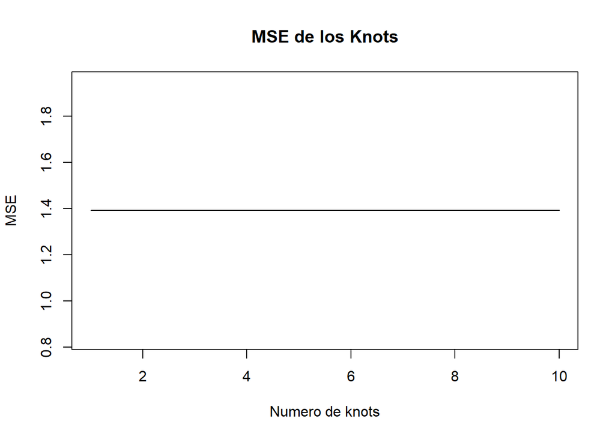

```r
k.values <- 1:10
mse <- sapply(k.values, reg_spline)

mean_mse <- sapply(k.values, function(k) mean(mse[k.values == k]))
plot(k.values, mean_mse, type = "l", xlab = "Numero de knots", ylab = "MSE", main = "MSE de los Knots")
```

```r
k.optimo <- k.values[which.min(mean_mse)]

cat("Numero optimo de knots:", k.optimo)
```

```
## Numero optimo de knots: 1
```

```r
polinomio.model <- lm(mpg ~ poly(horsepower, 2), data = train.data)
summary(polinomio.model)
```

```
##
## Call:
## lm(formula = mpg ~ poly(horsepower, 2), data = train.data)
##
## Residuals:
##     Min      1Q  Median      3Q     Max
## -14.610  -2.520  -0.054   2.303  14.915
##
## Coefficients:
##                       Estimate Std. Error t value Pr(>|t|)
## (Intercept)            23.3577     0.2282 102.343   <2e-16 ***
## poly(horsepower, 2)1 -113.4207     4.2820 -26.488   <2e-16 ***
## poly(horsepower, 2)2   40.2003     4.2820   9.388   <2e-16 ***
## ---
## Signif. codes:  0 '***' 0.001 '**' 0.01 '*' 0.05 '.' 0.1 ' ' 1
##
## Residual standard error: 4.282 on 349 degrees of freedom
## Multiple R-squared:  0.6935, Adjusted R-squared:  0.6918
## F-statistic: 394.9 on 2 and 349 DF,  p-value: < 2.2e-16
```

```r
spline.modelo <- gam(mpg ~ s(horsepower), data = train.data)
summary(spline.modelo)
```

```
##
## Family: gaussian
## Link function: identity
##
## Formula:
## mpg ~ s(horsepower)
##
## Parametric coefficients:
##             Estimate Std. Error t value Pr(>|t|)
## (Intercept)  23.3577     0.2238   104.4   <2e-16 ***
## ---
## Signif. codes:  0 '***' 0.001 '**' 0.01 '*' 0.05 '.' 0.1 ' ' 1
##
## Approximate significance of smooth terms:
##                 edf Ref.df     F p-value
## s(horsepower) 6.725  7.828 106.9  <2e-16 ***
## ---
## Signif. codes:  0 '***' 0.001 '**' 0.01 '*' 0.05 '.' 0.1 ' ' 1
##
## R-sq.(adj) =  0.704   Deviance explained = 70.9%
## GCV = 18.018  Scale est. = 17.623    n = 352
```

```r
modelo.reg.spline <- lm(mpg ~ ns(horsepower, knots = k.optimo), data = train.data)
summary(modelo.reg.spline)
```

```
##
## Call:
## lm(formula = mpg ~ ns(horsepower, knots = k.optimo), data = train.data)
##
## Residuals:
##      Min       1Q   Median       3Q      Max
## -13.4823  -3.1017  -0.2736   2.7368  17.0060
##
## Coefficients: (1 not defined because of singularities)
##                                   Estimate Std. Error t value Pr(>|t|)
## (Intercept)                       -118.375      5.985  -19.78   <2e-16 ***
## ns(horsepower, knots = k.optimo)1  273.619     11.544   23.70   <2e-16 ***
## ns(horsepower, knots = k.optimo)2       NA         NA      NA       NA
## ---
## Signif. codes:  0 '***' 0.001 '**' 0.01 '*' 0.05 '.' 0.1 ' ' 1
##
## Residual standard error: 4.785 on 350 degrees of freedom
## Multiple R-squared:  0.6161, Adjusted R-squared:  0.615
## F-statistic: 561.8 on 1 and 350 DF,  p-value: < 2.2e-16
```

```r
polinomio.cv <- cv.glm(train.data, polinomio.model, K = 10)
spline.cv <- cv.glm(train.data, spline.modelo, K = 10)
spline.suavizado.cv <- cv.glm(train.data, modelo.reg.spline, K = 10)
```

```r
polinomio.mse <- mean(polinomio.cv$delta**2)
polinomio.mse
```

```
## [1] NaN
```

```r
spline.mse <- mean(spline.cv$delta**2)
spline.mse
```

```
## [1] 322.4909
```

```r
spline.suavizado.mse <- mean(spline.suavizado.cv$delta**2)
spline.suavizado.mse
```

```
## [1] NaN
```

# tercer punto:

```r
locfit.model0 <- loess(mpg ~ horsepower, data = train.data, degree = 0)

locfit.model1 <- loess(mpg ~ horsepower, data = train.data, degree = 1)

locfit.model2 <- loess(mpg ~ horsepower, data = train.data, degree = 2)
```

```r
train.data$pred0 <- predict(locfit.model0, train.data)
train.data$pred1 <- predict(locfit.model1, train.data)
train.data$pred2 <- predict(locfit.model2, train.data)
```

```r
mse0 <- mean((train.data$mpg - train.data$pred0)^2)
mse1 <- mean((train.data$mpg - train.data$pred1)^2)
mse2 <- mean((train.data$mpg - train.data$pred2)^2)
```

```r
if (mse0 < mse1 & mse0 < mse2) {
  cat("El modelo de regresión local con kernel gaussiano de grado 0 es el mejor modelo.\n")
} else if (mse1 < mse0 & mse1 < mse2) {
  cat("El modelo de regresión local con kernel gaussiano de grado 1 es el mejor modelo.\n")
} else {
  cat("El modelo de regresión local con kernel gaussiano de grado 2 es el mejor modelo.\n")
}
```

```
## El modelo de regresión local con kernel gaussiano de grado 2 es el mejor modelo.
```

```r
bs.model <- lm(mpg ~ bs(horsepower, knots = 4), data = train.data)

locfit.model <- loess(mpg ~ horsepower, data = train.data, degree = 2)

poly.model <- lm(mpg ~ horsepower + I(horsepower^2), data = train.data)
```

```r
test.data$pred_bs <- predict(bs.model, test.data)
test.data$pred_locfit <- predict(locfit.model, test.data)
test.data$pred_poly <- predict(poly.model, test.data)
```

```r
mse_bs <- mean((test.data$mpg - test.data$pred_bs)^2)
mse_locfit <- mean((test.data$mpg - test.data$pred_locfit)^2)
mse_poly <- mean((test.data$mpg - test.data$pred_poly)^2)
```

```r
cat("El ECM de prueba para el modelo basado en base de funciones es", round(mse_bs, 3), "\n")
```

```
## El ECM de prueba para el modelo basado en base de funciones es 25.959
```

```r
cat("El ECM de prueba para el modelo basado en regresión local es", round(mse_locfit, 3), "\n")
```

```
## El ECM de prueba para el modelo basado en regresión local es 26.354
```

```r
cat("El ECM de prueba para el polinomio global de grado dos es", round(mse_poly, 3), "\n")
```

```
## El ECM de prueba para el polinomio global de grado dos es 26.168
```

**(7)** Escriba el estimador de Nadarya–Watson para la i-´esima unidad estadistica en t, es decir, x(t).

$$\hat{y}_i(t) = \frac{\sum_{j=1}^{n}
w_{ij} y_j}{\sum_{j=1}^{n} w_{ij}}$$

donde:

- $\hat{y}_i(t)$ es el valor estimado de la variable respuesta para la i-ésima unidad estadística en el punto t.
- $n$ es el número de observaciones en el conjunto de datos.
- $y_j$ es el valor observado de la variable respuesta para la j-ésima unidad estadística.
- $w_{ij}$ es el peso asignado a la j-ésima unidad estadística, definido como:

$$w_j = \frac{K(\frac{X_j -
t}{h})}{\sum_{j=1}^{n} K(\frac{X_j - t}{h})}$$

donde:

- $K$ es una función de núcleo simétrica y no negativa que integra a 1.
- $X_j$ es el valor observado de la variable independiente para la j-ésima unidad estadística.
- $h$ es un parámetro de suavizado que controla la amplitud del núcleo.